# Data Analysis with R

Victoria Mosby

2022-12-20

|  | Mean | SD | Min | Max | Median | P5 | P95 | N |
| --- | --- | --- | --- | --- | --- | --- | --- | --- |
| Age | 28.79 | 6.94 | 18 | 50 | 26.00 | 20.00 | 43.05 | 180 |
| Gender | 1.58 | 0.50 | 1.00 | 2.00 | 2.00 | 1.00 | 2.00 | 180 |
| Education | 15.57 | 1.62 | 12 | 21 | 16.00 | 14.00 | 18.00 | 180 |
| MaritalStatus | 1.41 | 0.49 | 1.00 | 2.00 | 1.00 | 1.00 | 2.00 | 180 |
| Usage | 3.46 | 1.08 | 2 | 7 | 3.00 | 2.00 | 5.05 | 180 |
| Fitness | 3.31 | 0.96 | 1 | 5 | 3.00 | 2.00 | 5.00 | 180 |
| Income | 53719.58 | 16506.68 | 29562 | 104581 | 50596.50 | 34053.15 | 90948.25 | 180 |
| Miles | 103.19 | 51.86 | 21 | 360 | 94.00 | 47.00 | 200.00 | 180 |

## Inpretation of the dataset

The average age of the users is 28 to 29 years of age (28.79) with the youngest being 18 years of age and the oldest being no more than 50 years of age. The median age however is 26 years old signifying a slightly right skewed distribution (mean is greater than median).

As the gender is 1.58 there are slightly more observations of men (2) than women (1).

Education is denoted in number of years. Someone with 12 years of education has completed high school, 16 years is someone with enough years to have completed a bachelors and 18 years is someone who has enough to have completed a masters degree. In this, the average user has 15.57 years of education. The minimum number in this dataset is 12 and the maximum is 21 years. The median number of years however is 16. This would indicate that the distribution is just slightly left skewed.

As the number for Marital Status is 1.41 with partnered being 1 and single being 2, there are slightly more users that are partnered than single.

Usage signifies the number of times the user plans to use the treadmill a week with a minimum of 2 and a maximum of 7. The average person said 3.46 or three/four times a week.

On a scale of 1 to 5, users rated themselves as not being very fit (1) to being in excellent condition (5). The average user believed themselves to be just above average at 3.31.

As for income; the minimim income a user reported was 29,562USD annually, and the maximum is 104,581USD annually. The average would be $53,719.58 while the median was $50,596.50. A slightly higher number of people had lower than 53,719.58USD making the distribution slightly right skewed.

Miles: according to this the average number of miles a user expected to run/walk a week was 103.19 miles. The minimum number of miles a week a user expected to complete was 21 with a maximum of 360. These people are incredibly optimistic.

Finally, the number of observations in the dataset are 180.

|  | Mean | SD | Min | Max | Median | P5 | P95 | N |
| --- | --- | --- | --- | --- | --- | --- | --- | --- |
| Age | 28.55 | 7.22 | 18 | 50 | 26.00 | 19.95 | 43.05 | 80 |
| Gender | 1.50 | 0.50 | 1.00 | 2.00 | 1.50 | 1.00 | 2.00 | 80 |
| Education | 15.04 | 1.22 | 12 | 18 | 16.00 | 13.00 | 16.00 | 80 |
| MaritalStatus | 1.40 | 0.49 | 1.00 | 2.00 | 1.00 | 1.00 | 2.00 | 80 |
| Usage | 3.09 | 0.78 | 2 | 5 | 3.00 | 2.00 | 4.00 | 80 |
| Fitness | 2.96 | 0.66 | 1 | 5 | 3.00 | 2.00 | 4.00 | 80 |
| Income | 46418.03 | 9075.78 | 29562 | 68220 | 46617.00 | 32973.00 | 60317.85 | 80 |
| Miles | 82.79 | 28.87 | 38 | 188 | 85.00 | 47.00 | 132.45 | 80 |

## Interpretation for Product TM195

In this dataset there are 80 observations.

The typical user for a Product TM195 is approximately 28 to 29 years old with an equal chance of being male or female. They have approximately 15 years of education, more than a high school graduation but less than a bachelors degree. They are slightly more likely to be partnered than to be single and expect to use the treadmill about 3 times a week. They would rate themselves as being slightly less fit than average and would like to run on average 82.79 miles a week. The average income of a user for this product is $46,418.03 per year; less than what the income of the overall dataset is.

|  | Mean | SD | Min | Max | Median | P5 | P95 | N |
| --- | --- | --- | --- | --- | --- | --- | --- | --- |
| Age | 28.90 | 6.65 | 19 | 48 | 26.00 | 20.00 | 40.00 | 60 |
| Gender | 1.52 | 0.50 | 1.00 | 2.00 | 2.00 | 1.00 | 2.00 | 60 |
| Education | 15.12 | 1.22 | 12 | 18 | 16.00 | 13.95 | 16.00 | 60 |
| MaritalStatus | 1.40 | 0.49 | 1.00 | 2.00 | 1.00 | 1.00 | 2.00 | 60 |
| Usage | 3.07 | 0.80 | 2 | 5 | 3.00 | 2.00 | 4.05 | 60 |
| Fitness | 2.90 | 0.63 | 1 | 4 | 3.00 | 2.00 | 4.00 | 60 |
| Income | 48973.65 | 8653.99 | 31836 | 67083 | 49459.50 | 34053.15 | 64809.00 | 60 |
| Miles | 87.93 | 33.26 | 21 | 212 | 85.00 | 42.00 | 129.15 | 60 |

## Interpretation for product TM498

In this dataset there are 60 observations.

The typical user for a Product TM498 is approximately 29 years old with a slightly higher chance of being male. They have approximately 15 years of education, more than a high school graduation but less than a bachelors degree. They are slightly more likely to be partnered than to be single and expect to use the treadmill about 3 times a week. They would rate themselves as being slightly less fit than average and less fit than the TM195 users and would like to run on average 87.93 miles a week. The minimum number of miles that a TM498 is 21 which is less than the minimum number of a TM195 at 38 miles per week. The average income of a user for this product is $48973.65 per year; less than what the income of the overall dataset is but greater than a TM195 user. The standard deviation for the income of this user is $8653.99 which is slightly less than the TM195 at $9075.78 meaning that the TM498 user income range has less variation than the TM195 users.

|  | Mean | SD | Min | Max | Median | P5 | P95 | N |
| --- | --- | --- | --- | --- | --- | --- | --- | --- |
| Age | 29.10 | 6.97 | 22 | 48 | 27.00 | 22.00 | 45.10 | 40 |
| Gender | 1.82 | 0.38 | 1.00 | 2.00 | 2.00 | 1.00 | 2.00 | 40 |
| Education | 17.32 | 1.64 | 14 | 21 | 18.00 | 15.90 | 21.00 | 40 |
| MaritalStatus | 1.43 | 0.50 | 1.00 | 2.00 | 1.00 | 1.00 | 2.00 | 40 |
| Usage | 4.78 | 0.95 | 3 | 7 | 5.00 | 4.00 | 6.05 | 40 |
| Fitness | 4.62 | 0.67 | 3 | 5 | 5.00 | 3.00 | 5.00 | 40 |
| Income | 75441.57 | 18505.84 | 48556 | 104581 | 76568.50 | 48652.90 | 103398.25 | 40 |
| Miles | 166.90 | 60.07 | 80 | 360 | 160.00 | 100.00 | 281.00 | 40 |

## Interpretation for product TM798

In this dataset there are 40 observations.

# Data Visualization

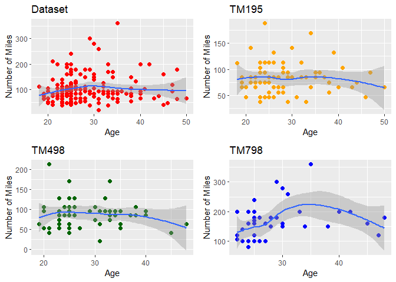

## Regressions

While I do not think regressions are necessary for understanding this particular dataset, it would be interesting to see the relationship behind the variables Age and Miles.

```
## OLS estimation, Dep. Var.: Age
## Observations: 180
## Standard-errors: Heteroskedasticity-robust
##              Estimate Std. Error   t value  Pr(>|t|)
## (Intercept) 28.282993   1.119123 25.272455 < 2.2e-16 ***
## Miles        0.004902   0.008973  0.546348   0.58551
## ---
## Signif. codes:  0 '***' 0.001 '**' 0.01 '*' 0.05 '.' 0.1 ' ' 1
## RMSE: 6.91954   Adj. R2: -0.00427
```

```
## OLS estimation, Dep. Var.: Age
## Observations: 80
## Standard-errors: Heteroskedasticity-robust
##              Estimate Std. Error   t value  Pr(>|t|)
## (Intercept) 29.888220   2.267303 13.182279 < 2.2e-16 ***
## Miles       -0.016165   0.024003 -0.673425   0.50267
## ---
## Signif. codes:  0 '***' 0.001 '**' 0.01 '*' 0.05 '.' 0.1 ' ' 1
## RMSE: 7.16117   Adj. R2: -0.00859
```

```
## OLS estimation, Dep. Var.: Age
## Observations: 60
## Standard-errors: Heteroskedasticity-robust
##              Estimate Std. Error  t value  Pr(>|t|)
## (Intercept) 31.090799   2.499599 12.43831 < 2.2e-16 ***
## Miles       -0.024914   0.023505 -1.05997   0.29355
## ---
## Signif. codes:  0 '***' 0.001 '**' 0.01 '*' 0.05 '.' 0.1 ' ' 1
## RMSE: 6.53819   Adj. R2: -0.001421
```

```
## OLS estimation, Dep. Var.: Age
## Observations: 40
## Standard-errors: Heteroskedasticity-robust
##              Estimate Std. Error  t value   Pr(>|t|)
## (Intercept) 24.390653   2.270168 10.74399 4.4761e-13 ***
## Miles        0.028217   0.011275  2.50255 1.6750e-02 *
## ---
## Signif. codes:  0 '***' 0.001 '**' 0.01 '*' 0.05 '.' 0.1 ' ' 1
## RMSE: 6.67752   Adj. R2: 0.03434
```

```
##
## ==================================================================
##                        Model 1     Model 2    Model 3    Model 4
## ------------------------------------------------------------------
## (Intercept)             28.28 ***  29.89 ***  31.09 ***  24.39 ***
##                         (1.12)     (2.27)     (2.50)     (2.27)
## Miles                    0.00      -0.02      -0.02       0.03 *
##                         (0.01)     (0.02)     (0.02)     (0.01)
## ------------------------------------------------------------------
## Num. obs.              180         80         60         40
## R^2 (full model)         0.00       0.00       0.02       0.06
## R^2 (proj model)
## Adj. R^2 (full model)   -0.00      -0.01      -0.00       0.03
## Adj. R^2 (proj model)
## ==================================================================
## *** p < 0.001; ** p < 0.01; * p < 0.05
```